# Flipping PC axes in geomorph plotGMPhyloMorphoSpace plots

2017-08-05

The `geomorph` R package provides a convenient function, `plotGMPhyloMorphoSpcae`, for plotting a phylogeny and Procrustes-aligned specimens in tangent space (Rohlf 2002; Klingenberg & Gidaszewski 2010). However, a limitation of this function is that it does not allow users to flip the direction of one or both principal axes. Although this might be a rarely used feature, I recently found myself in a situation where I wanted to do exactly this. In this post, I reproduce my situation and make a simple modification to the `plotGMPhyloMorphoSpcae` that allows the user to flip one or both principal axes.

### The situation

I have geometric morphometric data on skull shape for a sample of 62-63 primate species, with one male and one female specimen for each species (with a couple of exceptions). I am analyzing males and females separately, but given the strong correlation between male and female skulls from the same species, the analyses should produce similar results. I already cleaned and aligned the two datasets with Generalized Procrustes Alignment, and obtained phylogenetic trees for each dataset. The data can be imported from my website like this:

```r
# load packages
library("geomorph")
# import GPA aligned data for females and males
gpa.f <- readRDS(url("https://rgriff23.github.io/assets/Rds/diss_gpa_f.Rds"))
gpa.m <- readRDS(url("https://rgriff23.github.io/assets/Rds/diss_gpa_m.Rds"))

# import phylogenies for females and males
tree.f <- readRDS(url("https://rgriff23.github.io/assets/Rds/diss_tree_f.Rds"))
tree.m <- readRDS(url("https://rgriff23.github.io/assets/Rds/diss_tree_m.Rds"))
```

Now, generate side-by-side phylomorphospace plots using the `plotGMPhyloMorphoSpace` function (the plot parameters here serve to make the text a bit more readable, at least for peripheral species):

```r
# side-by-side phylomorphospace plots
layout(matrix(1:2, 1, 2))
plotGMPhyloMorphoSpace(tree.f, gpa.f$coords, plot.param=list(t.cex=0.3, n.cex=0.3, lwd=0.3, txt.cex=0.3))
```

[output not shown]

[output cut: 867 more lines]

```r
mtext("Females", line=1, cex=2)
plotGMPhyloMorphoSpace(tree.m, gpa.m$coords, plot.param=list(t.cex=0.3, n.cex=0.3, lwd=0.3, txt.cex=0.3))
```

[output not shown]

[output cut: 881 more lines]

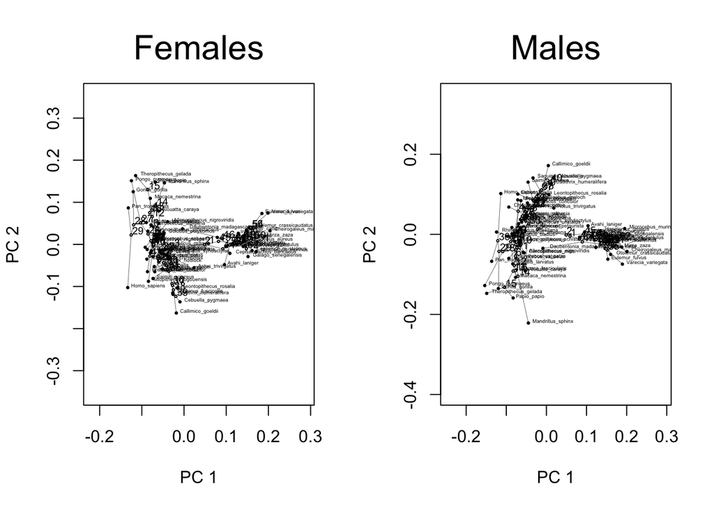

```r
mtext("Males", line=1, cex=2)
```

There isn’t anything *wrong* with these plots, but it is annoying that the y-axes in the two plots seem to go in opposite directions even though they actually describe the same axis of variation. In other words, the second plot looks an awful lot like the first plot if it were vertically flipped. This mismatch in plot orientations makes it more difficult to recognize that the second principal axis describes a very similar gradient, and more difficult to compare differences between the plots.

Here is how to load the function and produce the plots I want:

```r
# import function from GitHub
source(url("https://raw.githubusercontent.com/rgriff23/Dissertation/master/Chapter_5/R/plotGMPhyloMorphoSpace_axisflip.R"))

# side-by-side phylomorphospace plots with y-axis in male plot flipped
layout(matrix(1:2, 1, 2))
plotGMPhyloMorphoSpace_axisflip(tree.f, gpa.f$coords, plot.param=list(t.cex=0.3, n.cex=0.3, lwd=0.3, txt.cex=0.3))
```

[output not shown]

[output cut: 867 more lines]

```r
mtext("Females", line=1, cex=2)
plotGMPhyloMorphoSpace_axisflip(tree.m, gpa.m$coords, yaxis=-2, plot.param=list(t.cex=0.3, n.cex=0.3, lwd=0.3, txt.cex=0.3))
```

[output not shown]

[output cut: 881 more lines]

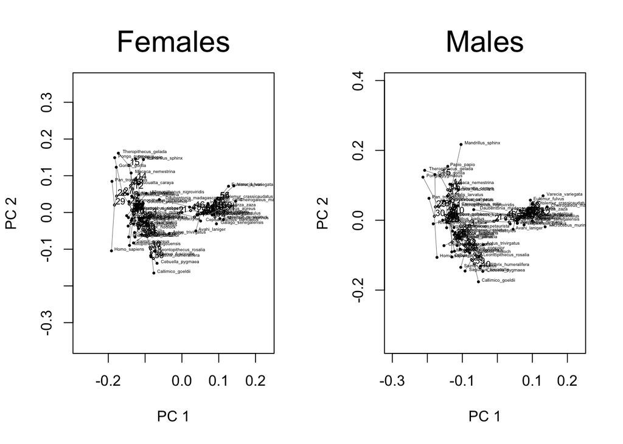

```r
mtext("Males", line=1, cex=2)
```

Now it is much easier to see that the two plots are quite similar, and it is also easier to compare their slight differences side by side. ___

**References**

Klingenberg, C. P., and N. A. Gidaszewski. 2010. Testing and quantifying phylogenetic signals and homoplasy in morphometric data. Syst. Biol. 59:245-261.

Rohlf, F. J. 2002. Geometric morphometrics and phylogeny. Pp.175-193 in N. Macleod, and P. Forey, eds. Morphology, shape, and phylogeny. Taylor & Francis, London.